# Final Assignment Analysis of Spatiotemporal Data

### Part III - Fitting Poisson point process with covariant

Intensities of a point processes can be modeled using Poisson point processes. Additionally a covariate can be introduced if the assumption is made that the point process is driven or at least influenced by the covariate [2]. To evaluate the quality of the resulting model a Poisson point process model is fitted without an additional covariate.

**Hypotheses Part III:**  
$H_{0} - III$: The wind turbine point pattern is not depended on the SEPD.

$Ha - III$: The wind turbine point pattern is depended on the SEPD.

The comparison between the models is carried out using the likelihood ratio test. The p-value ($Pr(>Chi)$) of such a test is interpreted as the probability of being wrong in rejecting the $H_{0}$ [2].

```r
covariantArnsberg <- as.im.RasterLayer(potentialYieldsArnsbergMasked)
ppmArnsbergCov <- ppm(pppArnsberg ~ covariantArnsberg, data=c(tessellationArnsberg))
ppmArnsberg <- ppm(pppArnsberg ~ 1)
ppmArnsbergPred <- predict(ppmArnsbergCov)

covariantDetmold <- as.im.RasterLayer(potentialYieldsDetmoldMasked)
ppmDetmoldCov <- ppm(pppDetmold ~ covariantDetmold, data=c(tessellationDetmold))
ppmDetmold <-ppm(pppDetmold ~ 1)
ppmDetmoldPred <- predict(ppmDetmoldCov)

covariantKöln <- as.im.RasterLayer(potentialYieldsKölnMasked)
ppmKölnCov <- ppm(pppKöln ~ covariantKöln, data=c(tessellationKöln))
ppmKöln <- ppm(pppKöln ~ 1)
ppmKölnPred <- predict(ppmKölnCov)

covariantDüsseldorf <- as.im.RasterLayer(potentialYieldsDüsseldorfMasked, )
ppmDüsseldorfCov <- ppm(pppDüsseldorf ~ covariantDüsseldorf, data=c(tessellationDüsseldorf))
ppmDüsseldorf <- ppm(pppDüsseldorf ~ 1)
ppmDüsseldorfPred <- predict(ppmDüsseldorfCov)

covariantMünster <- as.im.RasterLayer(potentialYieldsMünsterMasked)
ppmMünsterCov <- ppm(pppMünster ~ covariantMünster, data=c(tessellationMünster))
ppmMünster <- ppm(pppMünster ~ 1)
ppmMünsterPred <- predict(ppmMünsterCov)
```

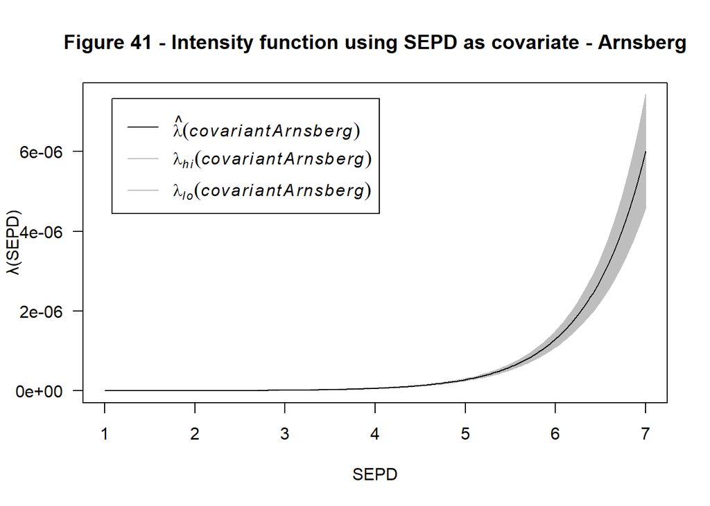

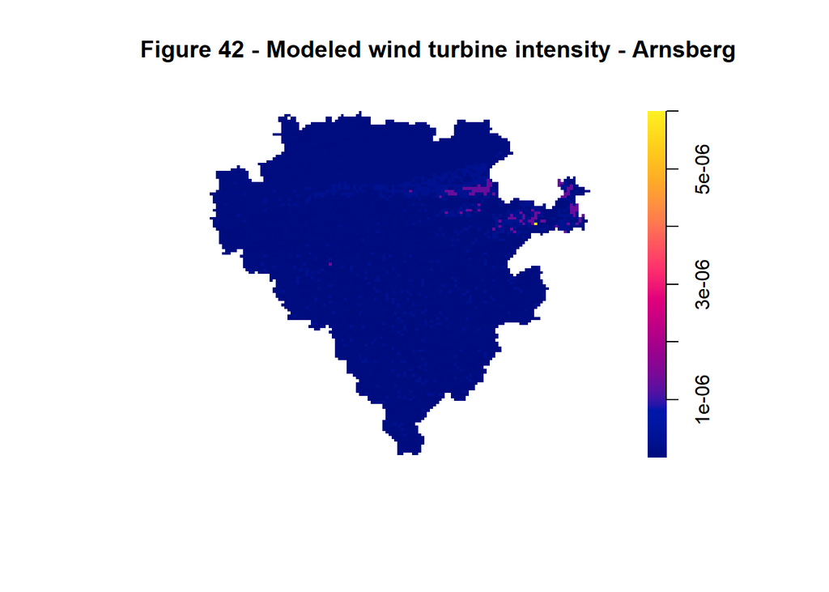

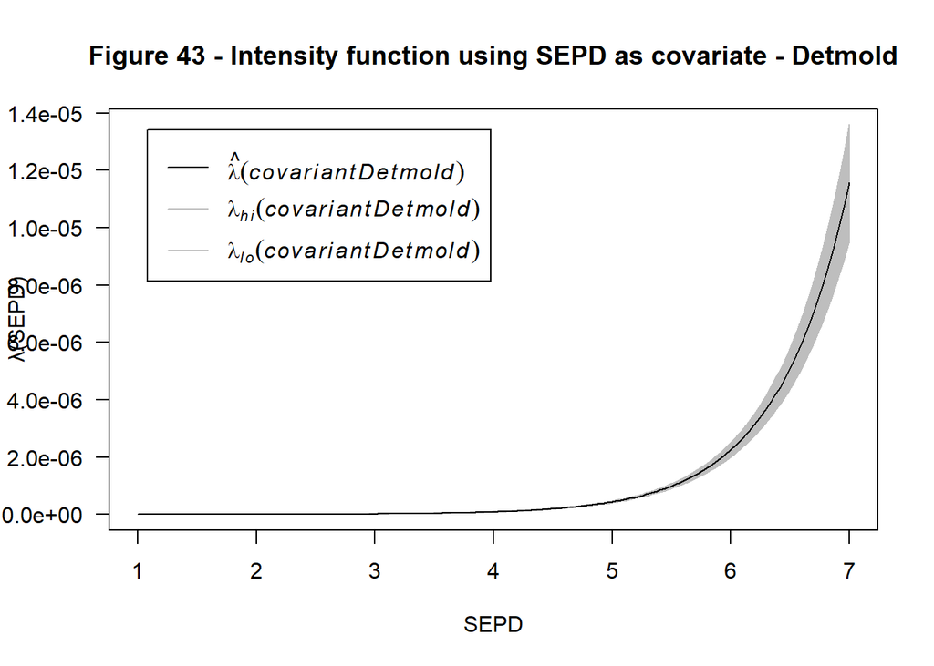

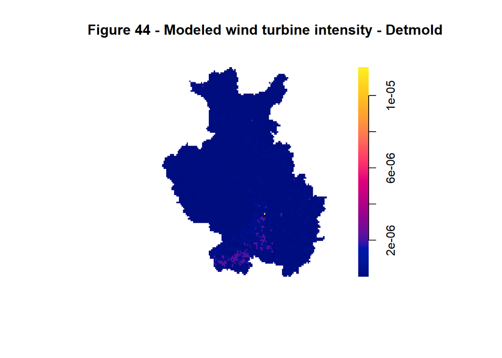

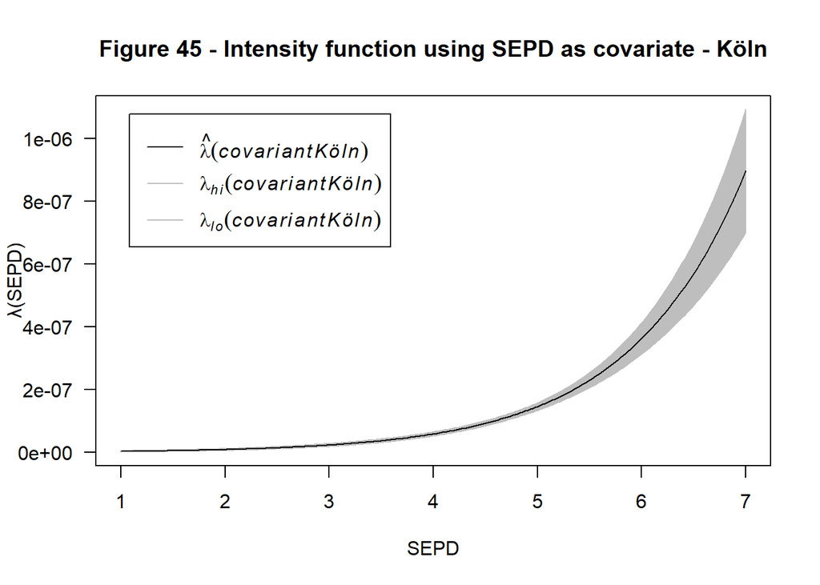

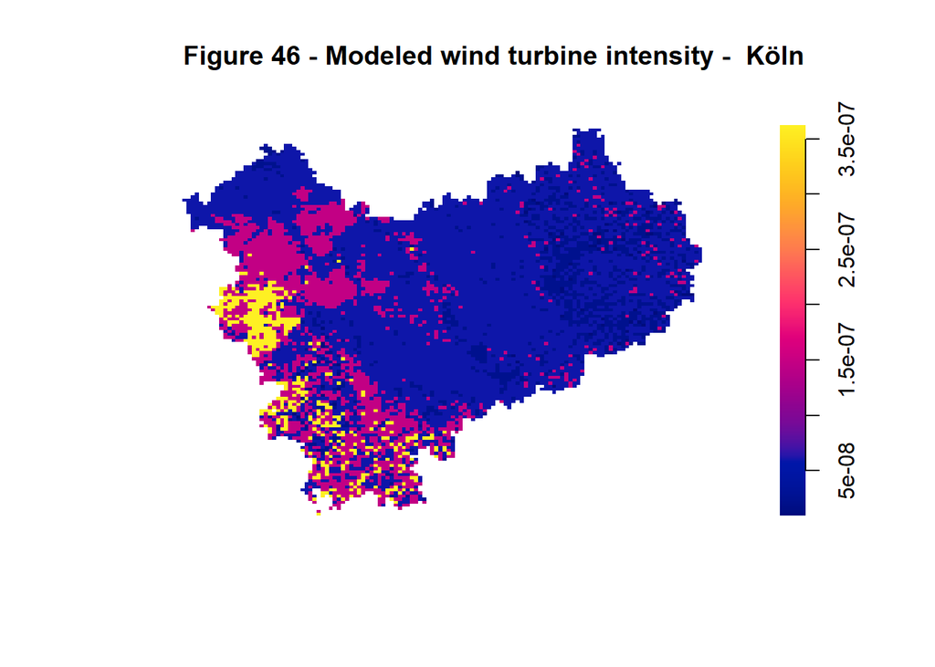

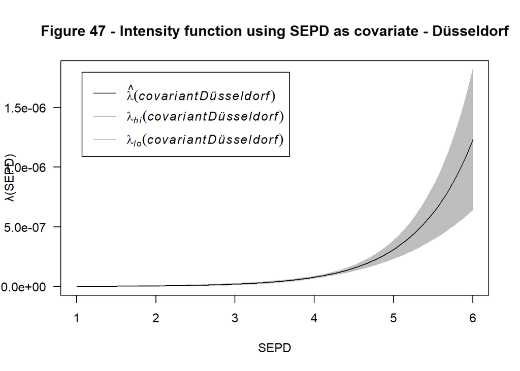

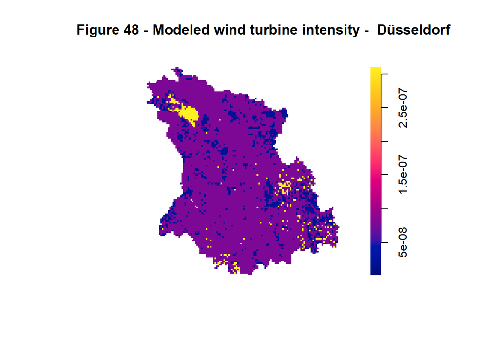

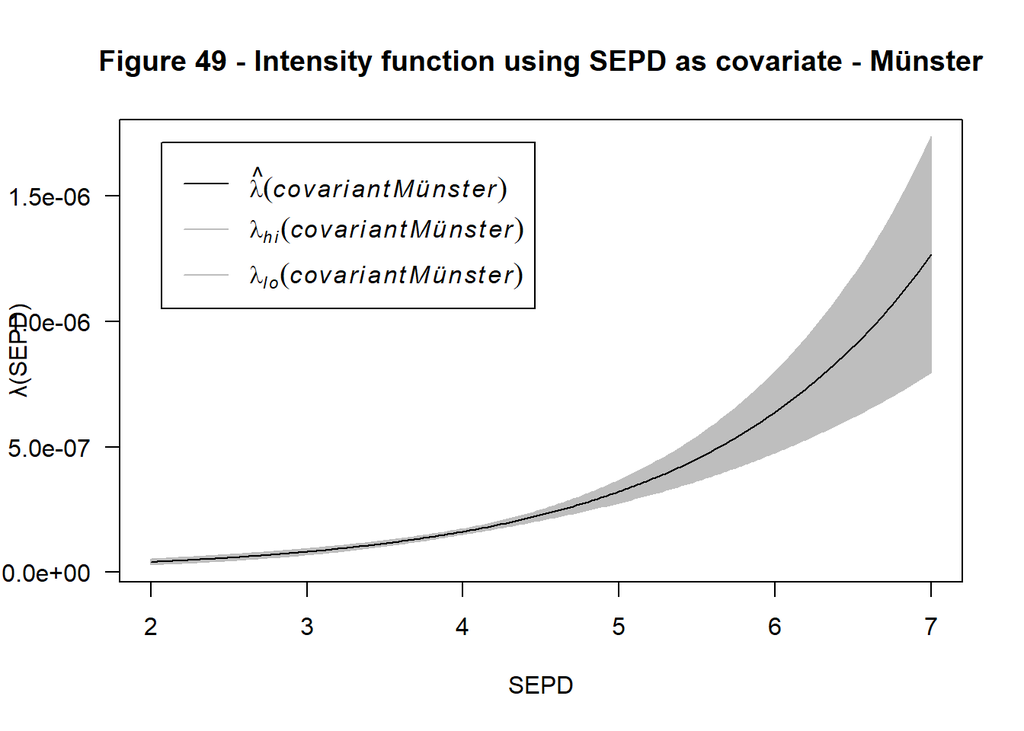

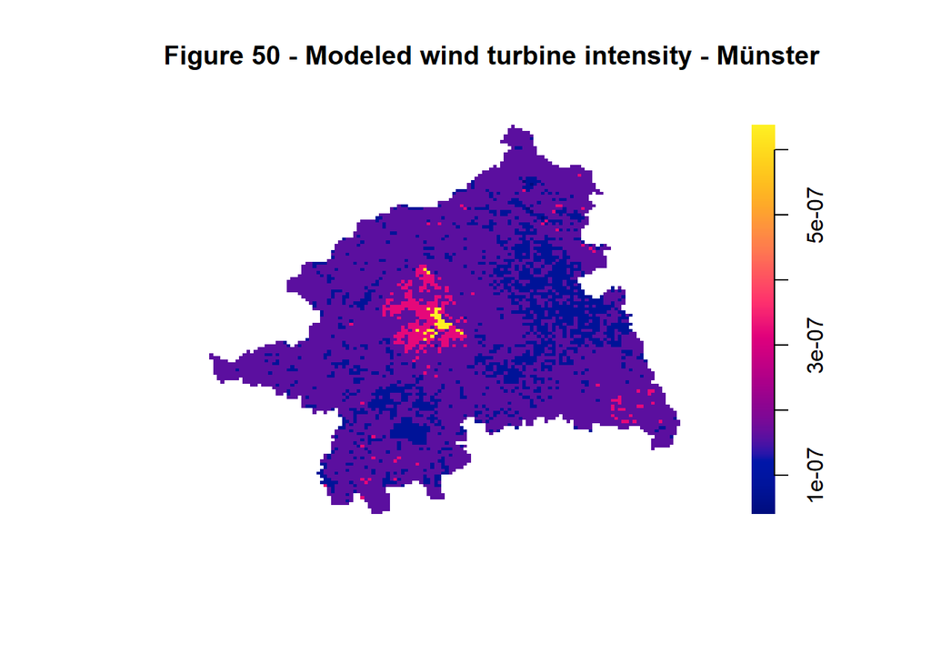

```r
anova(ppmArnsberg, ppmArnsbergCov, test="LR")
```

```
## Analysis of Deviance Table
##
## Model 1: ~1   Poisson
## Model 2: ~covariantArnsberg   Poisson
##   Npar Df Deviance  Pr(>Chi)
## 1    1
## 2    2  1   920.11 < 2.2e-16 ***
## ---
## Signif. codes:  0 '***' 0.001 '**' 0.01 '*' 0.05 '.' 0.1 ' ' 1
```

```r
anova(ppmDetmold, ppmDetmoldCov, test="LR")
```

```
## Analysis of Deviance Table
##
## Model 1: ~1   Poisson
## Model 2: ~covariantDetmold    Poisson
##   Npar Df Deviance  Pr(>Chi)
## 1    1
## 2    2  1   1486.5 < 2.2e-16 ***
## ---
## Signif. codes:  0 '***' 0.001 '**' 0.01 '*' 0.05 '.' 0.1 ' ' 1
```

```r
anova(ppmKöln, ppmKölnCov, test="LR")
```

```
## Analysis of Deviance Table
##
## Model 1: ~1   Poisson
## Model 2: ~covariantKöln   Poisson
##   Npar Df Deviance  Pr(>Chi)
## 1    1
## 2    2  1   365.89 < 2.2e-16 ***
## ---
## Signif. codes:  0 '***' 0.001 '**' 0.01 '*' 0.05 '.' 0.1 ' ' 1
```

```r
anova(ppmDüsseldorf, ppmDüsseldorfCov, test="LR")
```

```
## Analysis of Deviance Table
##
## Model 1: ~1   Poisson
## Model 2: ~covariantDüsseldorf     Poisson
##   Npar Df Deviance  Pr(>Chi)
## 1    1
## 2    2  1   116.21 < 2.2e-16 ***
## ---
## Signif. codes:  0 '***' 0.001 '**' 0.01 '*' 0.05 '.' 0.1 ' ' 1
```

```r
anova(ppmMünster, ppmMünsterCov, test="LR")
```

```
## Analysis of Deviance Table
##
## Model 1: ~1   Poisson
## Model 2: ~covariantMünster    Poisson
##   Npar Df Deviance  Pr(>Chi)
## 1    1
## 2    2  1   116.11 < 2.2e-16 ***
## ---
## Signif. codes:  0 '***' 0.001 '**' 0.01 '*' 0.05 '.' 0.1 ' ' 1
```